# Strategy & Slate Planning_044

Author

Somya, Shravani, Urvi

### 0.0.1 Task 1 Slate Health Check

Data Cleaning

### 0.0.2 Summary tables

Summary Statistics for Movie Budgets

| n | mean | median | sd | Q1 | Q3 | max |
| --- | --- | --- | --- | --- | --- | --- |
| 3766 | 37 | 23 | 42.6 | 8 | 50 | 380 |

Summary Statistics for Return on Investment (ROI)

| n | mean | median | sd | Q1 | Q3 | max |
| --- | --- | --- | --- | --- | --- | --- |
| 3229 | 2954.82 | 2.3 | 150610.1 | 1.02 | 4.42 | 8500000 |

**Note: To make visualisation clear, the genres are divided into categories, with a standard of more and less than 250 movies per genre for further analysis.**

## 0.1 Overall Production Budget Distribution

Figure 1 shows a positively skewed distribution of production budgets.This suggests that high production budgets are relatively uncommon, while most films are produced with more modest budgets. The Head of Production should consider this skewed distribution when planning future budgets, as a small number of high-budget films may influence the overall mean.

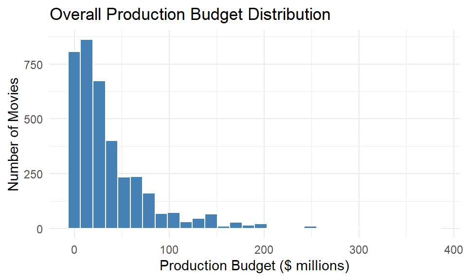

Figure 1: Overall production budget distribution across all genres.

#### 0.1.0.1 Production Budget Acorss Genre

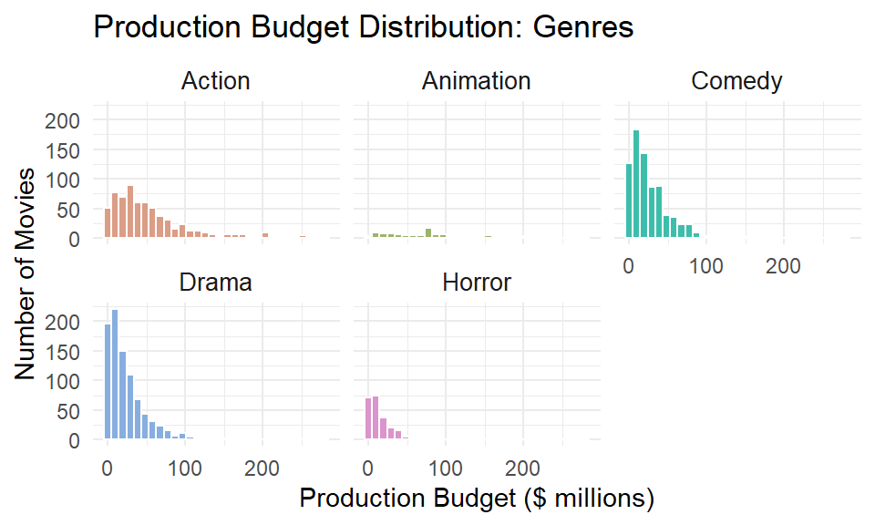

Figure 2: Production budget distribution for genres.

## 0.2 ROI distribution (Overall and by genre)

In Figure 3 distribution is concentrated around a revenue-to-budget ratio of approximately 1, with a right-skewed tail extending towards much higher values. Most films have ratios relatively close to the central range, but a small number achieve exceptionally high revenue relative to their production budgets.

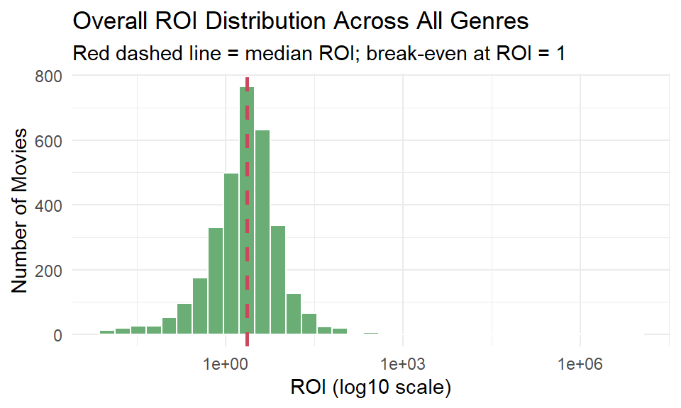

Figure 3: Overall distribution of revenue-to-budget ratios across the selected genres.

## 0.3 Franchise and Original Film Composition

The overall slate is dominated by original films, which account for 94.6% of films, while franchises represent only 5.4%. This indicates that the historical slate relies mainly on standalone productions rather than established franchises.

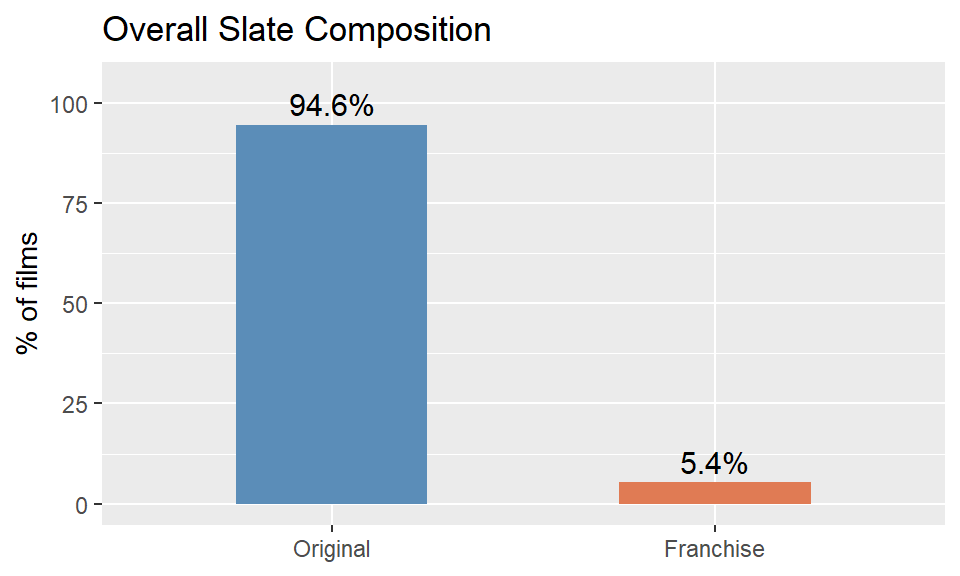

## 0.4 Slate Trends Over Time (2000–2016)

Franchise share increased towards 2016, reaching approximately 16%. Median production budgets generally declined from around $33 million in 2000 to $22 million in 2014–2015, before recovering slightly. In contrast, median ROI increased after 2010, reaching approximately 2.9 in 2016.

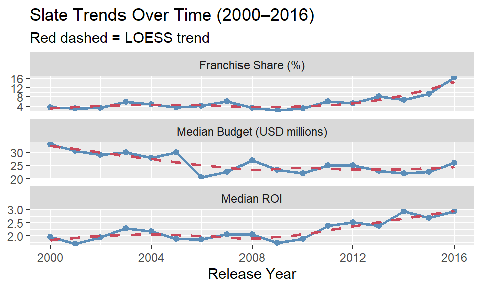

The Head of Production should consider these differences when evaluating opportunities to develop new original projects or invest in franchise films. However, the percentages describe the composition of the slate rather than financial success, so they should be considered alongside budget and ROI results before making investment decisions.

## 0.5 Summary for the Head of Production

ROI varies across genres, with some films earning well above their production budgets. From 2000 to 2016, median ROI generally increased after 2010, reaching approximately 2.9 in 2016. Median budgets declined before recovering slightly, while franchise share rose to around 16%.

Zero budgets and revenues were treated as missing, and blank text values were converted to NA. Records with invalid budgets or missing genres were excluded from relevant plots, but the original dataset was retained. These limitations should be considered when using budget, ROI, genre and franchise trends to guide production decisions.

# 1 Task 2

Table 1: Films with and without a usable budget, by franchise status

| Franchise status | Films | Usable budget | Missing budget | % missing |
| --- | --- | --- | --- | --- |
| Franchise | 260 | 260 | 0 | 0 |
| Original | 4543 | 4543 | 0 | 0 |

### 1.0.1 1. Comparing the budget distributions

Franchise films generally have higher production budgets than original films, although the distributions overlap considerably. Original films are more concentrated at lower budgets, while franchises tend towards higher spending.

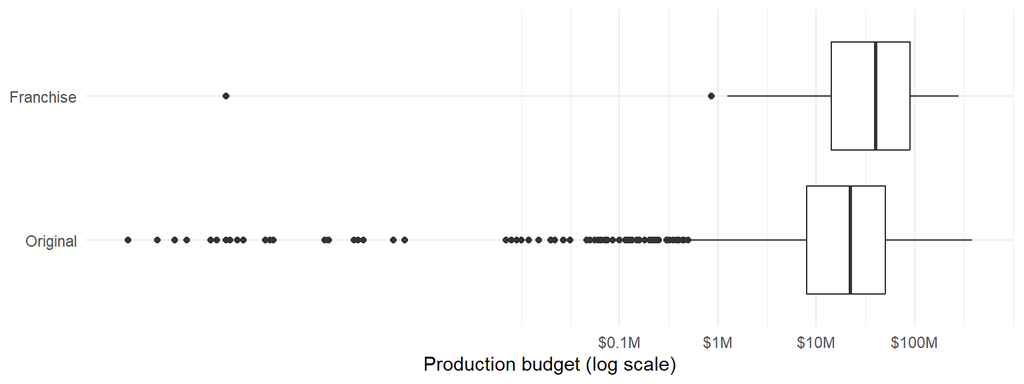

Figure 4: Budget by franchise status (log scale). The line in each box is the median.

Figure 4 confirms that franchise films have a higher median budget than original films. However, both groups show substantial variation, indicating that franchise status alone does not determine production spending.

### 1.0.2 2. Interval estimate for the difference in median budget

We used a 95% percentile bootstrap interval: each group was resampled with replacement at its own size, Franchise median minus Original median was calculated, this was repeated 5,000 times, and the middle 95% was taken. All calculations are in dollars.

Table 2: Difference in median budget (Franchise minus Original) with 95% bootstrap interval (USD millions)

| Observed difference | Lower 95% | Upper 95% |
| --- | --- | --- |
| 18 | 10 | 26 |

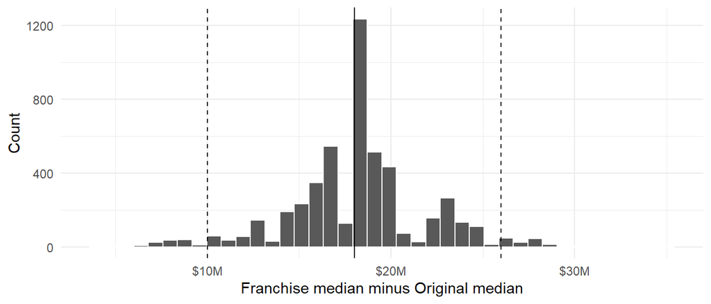

Figure 5: Bootstrap distribution of the difference in median budget. Solid line: observed difference. Dashed lines: 95% interval.

The observed difference in median budget is $18M, and the 95% interval runs from $10M to $26M (Table 2, Figure 5). The interval does not include zero, so the typical Franchise budget is higher than the typical Original budget.

### 1.0.3 3. Does this support leadership’s concern?

Table 3: Share of films and budget, and proportion of low and high budgets, by franchise status

| Franchise status | Films | Share of films | Share of budget | Under $10M | Over $100M |
| --- | --- | --- | --- | --- | --- |
| Original | 4543 | 0.946 | NA | NA | NA |
| Franchise | 260 | 0.054 | NA | NA | NA |

Table 4: Share of total revenue by franchise status (films with revenue recorded)

| Franchise status | Total revenue | Share of revenue |
| --- | --- | --- |
| Franchise | 56198351944 | 0.142 |
| Original | 338899495500 | 0.858 |

### 1.0.4 4. Investment advice

# 2 Task 3

## 2.1 Part A

Universal Pictures was selected as Meridian Pictures’ benchmark. After filtering invalid budgets, 260 films remained. The mean budget was $41.57 million, the median was $30.50 million, and the standard deviation was $37.89 million. The higher mean indicates right-skewness, while the large standard deviation shows substantial budget variation. Therefore, a probability distribution is more useful than a single average for modelling production costs.

### 2.1.1 Assessment of the Normal Distribution

Universal Pictures’ production budgets are positively skewed, with most films having lower budgets and a few requiring much higher investment. The fitted normal curve does not capture this asymmetry, suggesting that a right-skewed distribution may better represent production budgets and their associated probabilities.

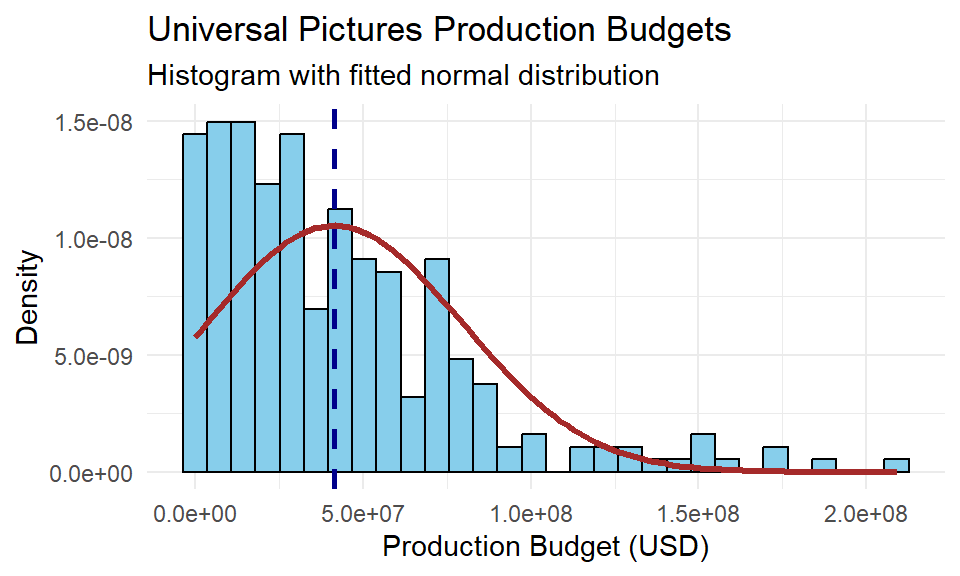

## 2.2 Choice of the alternative distribution and modelling

**Note :Budgets were then divided by 10,000,000 to improve numerical convenience during model estimation while preserving their relative distribution.**

## 2.3 Graphical Representation of Model Choice

Figure 6 compares the Gamma, Exponential and Weibull distributions fitted to Universal Pictures’ production budgets. The observed budgets are positively skewed, with most films concentrated at lower budget levels and a smaller number of films having substantially higher budgets.

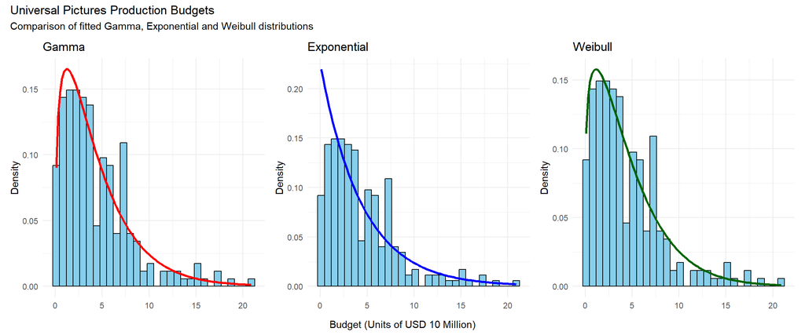

Figure 6: Comparison of fitted Gamma, Exponential and Weibull distributions for Universal Pictures’ production budgets.

The Figure 7 compare the observed production budgets of Universal Pictures with the fitted Gamma, Exponential and Weibull distributions. The Gamma and Weibull distributions align more closely with the reference line across most of the budget range, although both deviate for higher-budget films. The Exponential distribution shows greater deviation, suggesting a weaker fit.

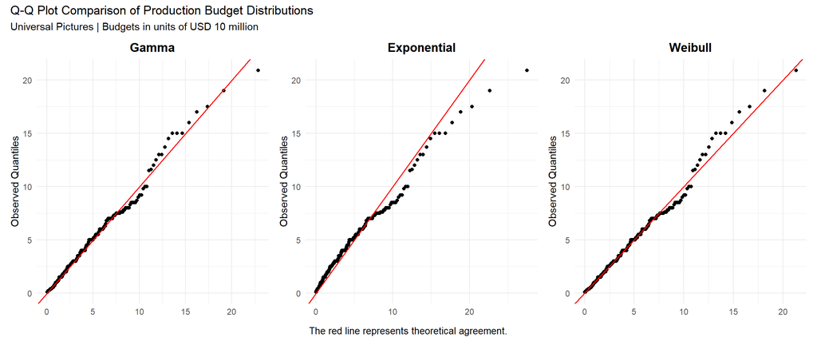

Figure 7: Q-Q plots comparing Gamma, Exponential and Weibull distributions fitted to Universal Pictures’ production budgets.

## 2.4 Comparing the AIC for Decision making

The AIC results indicate that the Gamma distribution provides the best relative fit for Universal Pictures’ production budgets, with a score of 1201.090. The Weibull distribution performs almost equally well (1201.542), while the Exponential distribution has a higher AIC (1213.346), indicating a weaker fit. For Meridian Pictures, Gamma is therefore the preferred model for estimating historical budget patterns, although Weibull remains a reasonable alternative.

Comparison of Fitted Distributions

Akaike Information Criterion (AIC)

| Distribution | AIC Value |
| --- | --- |
| Gamma | 1,201.090 |
| Exponential | 1,213.346 |
| Weibull | 1,201.542 |

Lower AIC values indicate a better relative model fit.

## 2.5 Part B

Action films across all studios were analysed to assess downside risk. Numeric variables were checked for missing, zero, negative and infinite values. Zero-budget films were identified because ROI cannot be reliably calculated, while missing and infinite ROI values were excluded. Valid zero and negative ROI values were retained as potentially genuine financial outcomes.

The 25th percentile of ROI was estimated using non-parametric bootstrapping with 15,000 resamples. This method repeatedly resamples the observed ROI values with replacement, without assuming a specific probability distribution.

# 3 Part C

A normal parametric bootstrap was initially used to compare the results with the non-parametric method. The normal distribution accommodates both positive and negative ROI values, unlike the standard Gamma and Weibull distributions, which require strictly positive values.

The **non-parametric bootstrap** is preferred because it preserves the observed distribution without assuming normality. For Meridian Pictures, this provides a more defensible estimate of lower-end ROI, supporting investment decisions that account for the actual variation in Action-film returns.

Table 5: Comparison of 25th Percentile ROI Estimates and 95% Confidence Intervals

Comparison of Action Film ROI Estimates

25th Percentile and 95% Confidence Intervals

| Estimation Method | Estimated Q25 | Lower Limit | Upper Limit | Assessment |
| --- | --- | --- | --- | --- |
| Non-parametric bootstrap | 0.5764 | 0.4669 | 0.6763 | Preferred: preserves the observed ROI distribution |
| Normal parametric bootstrap | −0.8080 | −1.3247 | −0.2738 | Less suitable: assumes normally distributed ROI |

# 4 Part D

Universal Pictures’ production budgets are positively skewed, making the Gamma distribution more suitable than the normal distribution for simulating budget patterns. For Action films, the non-parametric bootstrap estimates the lower-quarter revenue-to-budget ratio at 0.5764, with a confidence interval of approximately 0.467–0.676.

This suggests that lower-performing Action films generate around 58 cents in revenue per $1 of production budget. This is not a 58% profit or return, as the ratio excludes other costs.

The confidence interval communicates uncertainty around the estimate. Together, these findings help Meridian Pictures simulate realistic budgets and assess potential downside risk when planning future productions.

# 5 Task 4

#Part A: Defining the outcome and justifying the model

A film is defined as a **flop** if it fails to recoup its production budget at the box office, i.e. ROI < 1. This is created as a binary variable: 1 = flop, 0 = not a flop.

### 5.0.1 Why Logistic Regression?

We use logistic regression to predict whether a film will flop, making this a binary classification problem. Unlike linear regression, which predicts continuous values, logistic regression estimates probabilities between 0 and 1.

Poisson regression is mainly used for count data. Logistic regression also helps Meridian Pictures understand how factors such as genre, budget and franchise status affect flop probability, supporting more informed greenlight decisions.

### 5.0.2 Part B

**Note: Action was selected as the reference genre because its downside risk was examined in the earlier analysis.**

Frequentist and Bayesian logistic regression models were fitted to 2,256 movies. Both produced similar odds ratios and intervals. Animation, Horror, franchise status and cast size were associated with lower flop odds, while Comedy, Drama and log budget showed greater uncertainty. For example, franchise films had approximately 75% lower flop odds than Original films.

The frequentist and Bayesian intervals were similar. For Animation, the 95% confidence interval was 0.273–0.826, compared with the Bayesian credible interval of 0.275–0.814. For franchise status, the intervals were 0.124–0.444 and 0.127–0.438, respectively. Both intervals lie below 1, indicating lower flop odds. The posterior probability that franchise films have lower flop odds than Original films was approximately 100%, providing strong evidence for this association.

The posterior probability that franchise films have lower odds of flopping than Original films is approximately 100%, after controlling for genre, log budget and cast size.

# 6 Appendix: Key Code for Reproducibility

The following condensed code excerpts summarise the main analytical steps used in the report. The complete executable code remains in the project source file.

## 6.1 A. Data cleaning and derived variables

```r
movies_clean <- movies |>
  mutate(
    budget = if_else(budget == 0, NA_real_, as.numeric(budget)),
    revenue = if_else(revenue == 0, NA_real_, as.numeric(revenue)),
    roi = revenue / budget,
    budget_m = budget / 1e6,
    franchise_status = factor(
      franchise_status,
      levels = c("Original", "Franchise")
    )
  )
```

## 6.2 B. Summary statistics and visualisation

```r
movies_clean |>
  summarise(
    n = sum(!is.na(budget_m)),
    median_budget = median(budget_m, na.rm = TRUE),
    median_roi = median(roi, na.rm = TRUE)
  )

ggplot(movies_clean, aes(x = budget_m)) +
  geom_histogram(bins = 30, colour = "white") +
  labs(x = "Production budget ($ millions)", y = "Number of films") +
  theme_minimal()
```

## 6.3 C. Bootstrap interval for the median-budget difference

```r
set.seed(100)
B <- 5000

boot_diff <- replicate(B, {
  original <- t2 |> filter(franchise_status == "Original") |>
    pull(budget) |> na.omit()
  franchise <- t2 |> filter(franchise_status == "Franchise") |>
    pull(budget) |> na.omit()
  median(sample(franchise, replace = TRUE)) -
    median(sample(original, replace = TRUE))
})

quantile(boot_diff, c(0.025, 0.975), na.rm = TRUE)
```

## 6.4 D. Distribution fitting and logistic regression

```r
budget_values <- Universal_budget |>
  filter(!is.na(budget), is.finite(budget), budget > 0) |>
  pull(budget) / 1e7

gamma_fit <- MASS::fitdistr(budget_values, "gamma")
weibull_fit <- MASS::fitdistr(budget_values, "weibull")
exponential_fit <- MASS::fitdistr(budget_values, "exponential")

movies_model2 <- movies_clean |>
  filter(!is.na(roi)) |>
  mutate(flop = as.integer(roi < 1), log_budget = log(budget)) |>
  filter(is.finite(log_budget), !is.na(cast_size),
         !is.na(primary_genre), !is.na(franchise_status))

model_freq <- glm(
  flop ~ primary_genre + franchise_status + log_budget + cast_size,
  data = movies_model2,
  family = binomial(link = "logit")
)
```

## 6.5 E. Bayesian logistic regression

```r
bayesian_model <- rstanarm::stan_glm(
  flop ~ primary_genre + franchise_status + log_budget + cast_size,
  data = movies_model2,
  family = binomial(link = "logit"),
  prior = normal(0, 2.5, autoscale = FALSE),
  prior_intercept = normal(0, 2.5, autoscale = FALSE),
  chains = 4, iter = 4000, seed = 123, refresh = 500
)
```